# Station Casino: Gaming Analytics

Krishna Prasad

14 August, 2019

# Introduction

Station Casinos is the leading provider of gaming and entertainment to the local residents of Las Vegas, Nevada. As the largest non-union gaming company in the country, Station Casinos owns and operates 18 casino and/or hotel properties in the Las Vegas area. Founded by Frank Fertitta Jr. in 1976, the first property was opened as ‘The Casino’, home of the famous Bingo Parlor (later to become Palace Station). The business model was to cater to local residents operating from less expensive real estate on the periphery of town, rather than competing for tourist dollars on the expensive ‘Strip’ of Las Vegas Boulevard.

[figure not shown]

Today, they continue to serve the Las Vegas locals. Station Casinos earned the loyalty of their customers by consistently delivering a friendly and fair gaming experience. Part of Station Casinos’ popularity with the locals, a group very sophisticated in gaming, comes from their policy to maintain, on average, a lower hold, or house win percentage, than other casinos. In other words, the casino keeps less of the money played, allowing for longer play time for customers.

# Problem

Using the complete data provided (5000 players in one day), we will answer few critical questions for the Station Casino management. With our background understanding on the problem, we will first analyse the amounts bet on all the games and number of people who played different games. With these insights we will create groupings that will assist management to determine what type of comps need to be offered.

Below is the snapshot of the data provided

```
## Observations: 5,000
## Variables: 9
## $ Player        <chr> "Player 1", "Player 2", "Player 3", "Player 4", "P…
## $ Slots         <dbl> 1013, 68, 148, 63, 92, 658, 358, 139, 673, 65, 59,…
## $ BJ            <dbl> 6190, 23, 0, 17, 44, 0, 359, 0, 279, 15, 39, 0, 39…
## $ Craps         <dbl> 4276, 23, 0, 28, 18, 0, 172, 0, 103, 10, 35, 565, …
## $ Bac           <dbl> 868, 12, 0, 9, 10, 0, 103, 0, 103, 12, 7, 0, 5, 10…
## $ Bingo         <dbl> 0, 0, 0, 0, 0, 106, 0, 0, 0, 0, 0, 0, 0, 0, 0, 0, …
## $ Poker         <dbl> 0, 28, 0, 23, 26, 0, 258, 0, 161, 26, 18, 0, 10, 2…
## $ Other         <dbl> 0, 53, 0, 52, 60, 0, 422, 0, 546, 69, 52, 0, 48, 4…
## $ `Total Spend` <dbl> 12348, 207, 148, 193, 250, 764, 1671, 139, 1866, 1…
```

### How much total dollars were played on each game?

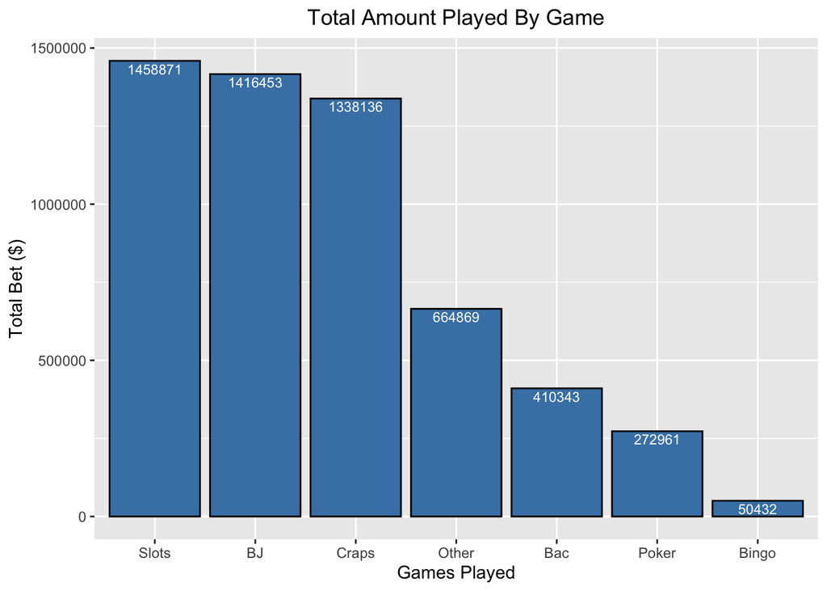

### How many people played each of the seven games and how much did they wager?

**Analysis:**

One easy way to analyse how many people played, how much each wagered and segment them based on their spend levels is by plotting histograms for each game.

Below are the histograms showing the number of players and the amount spent for each game with the red line being the average amount spent for each game.

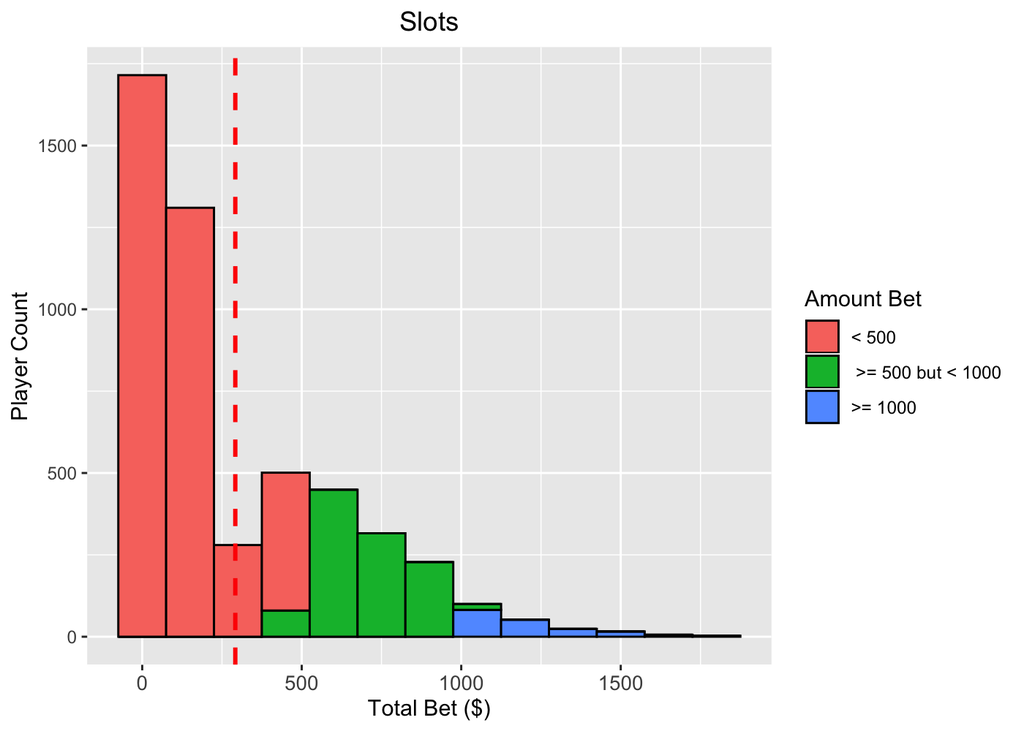

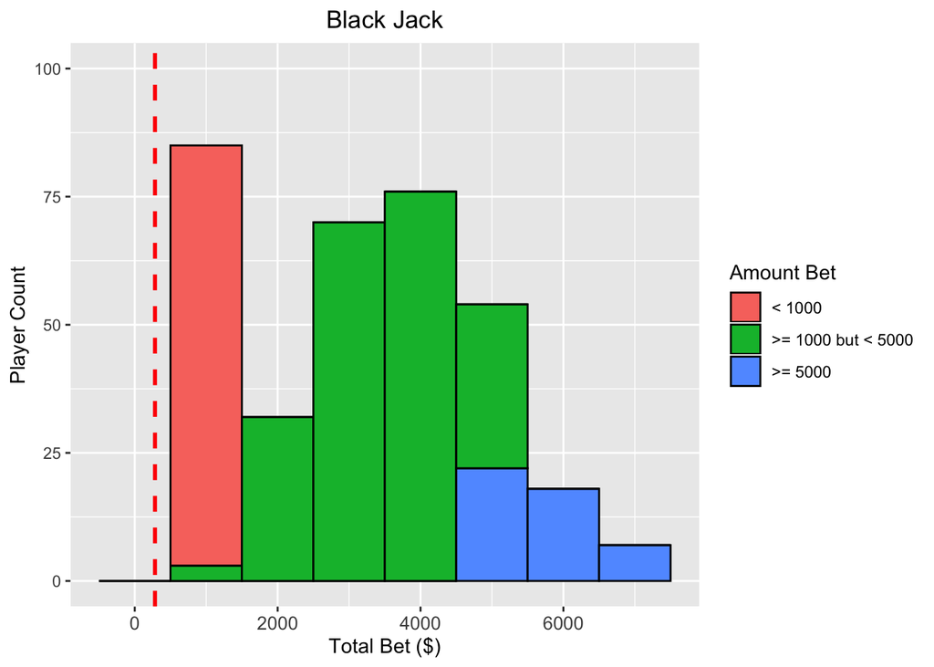

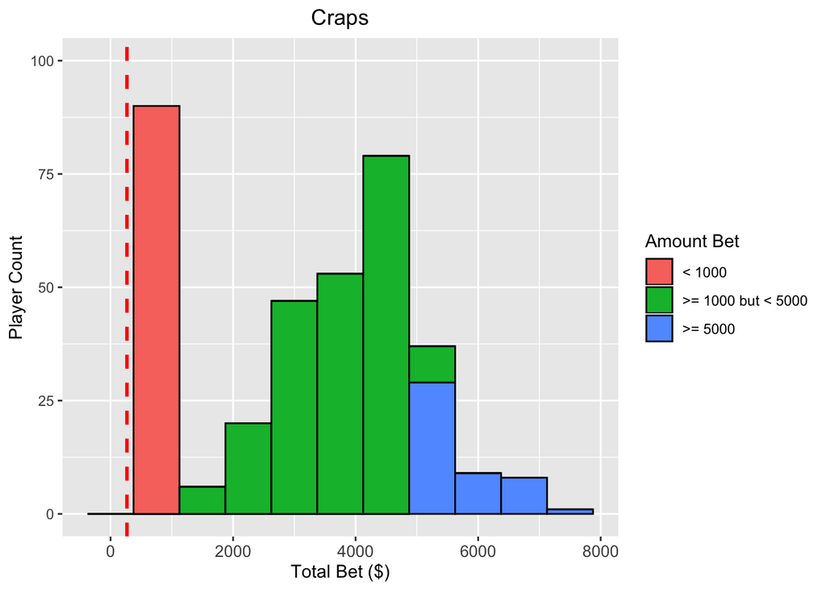

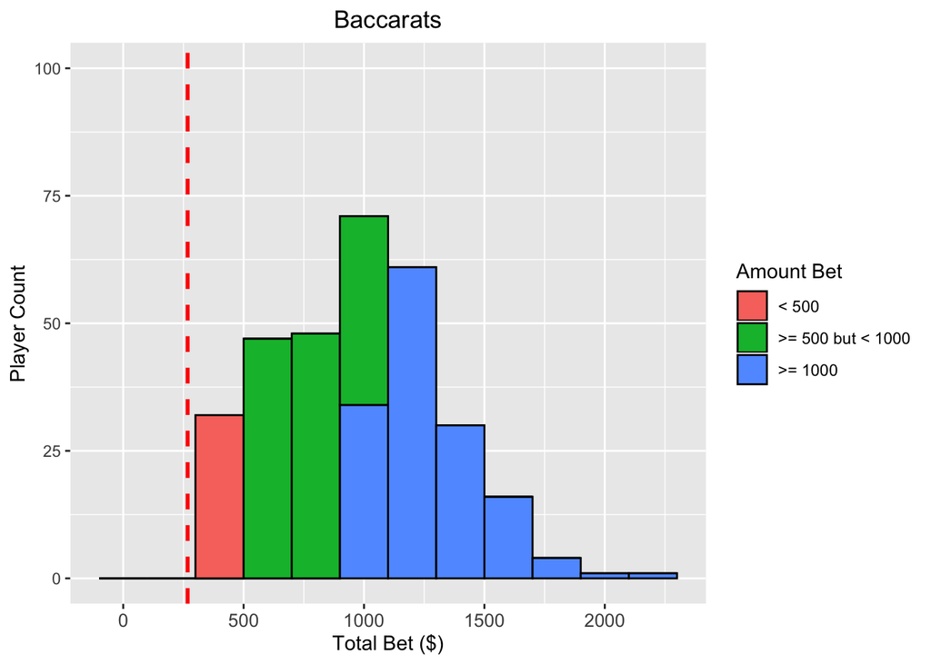

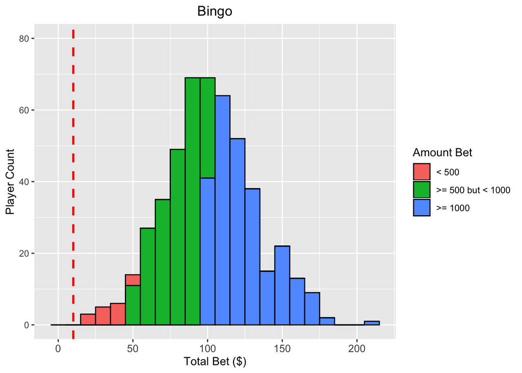

**Bingo:** On an average, players spent ~$10 on Bingo with majority of the players spending anywhere between $25-$200. There are very few players who have spent above or below the $25-$200 range.

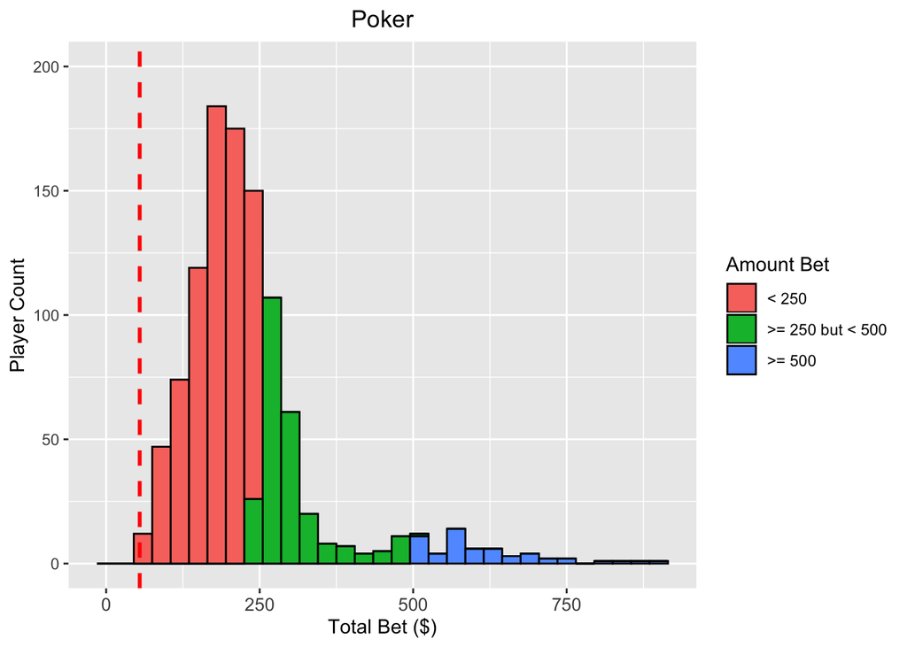

**Poker:** On an average, players spent ~$55 on Poker with majority of the players spending less than $250. There are very few players who have spent money more than $300.

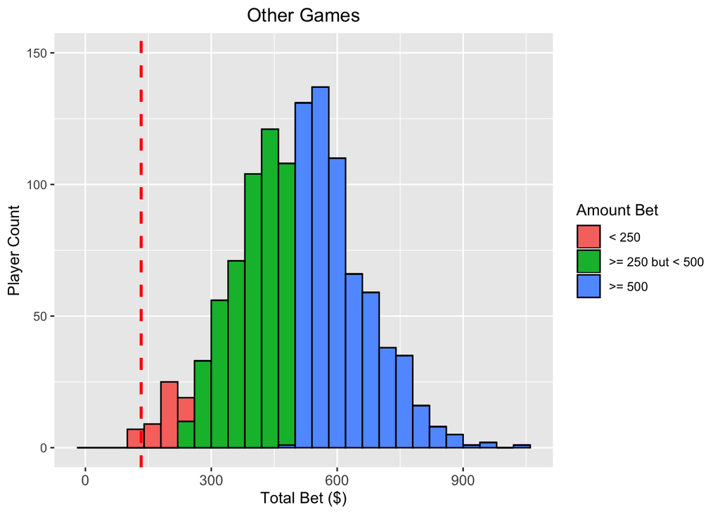

**Other Games:** On an average, players spent ~$130 on Other games with players equally distributed on the spend. There are fair amount of players who have spent money between the $250-$900 range playing these kind of games.

```
## $`1`
```

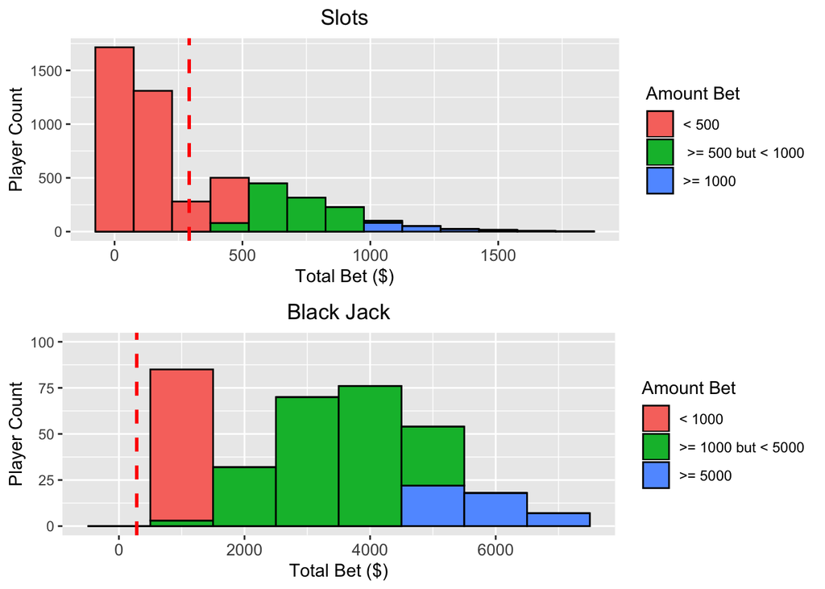

```
##
## $`2`
```

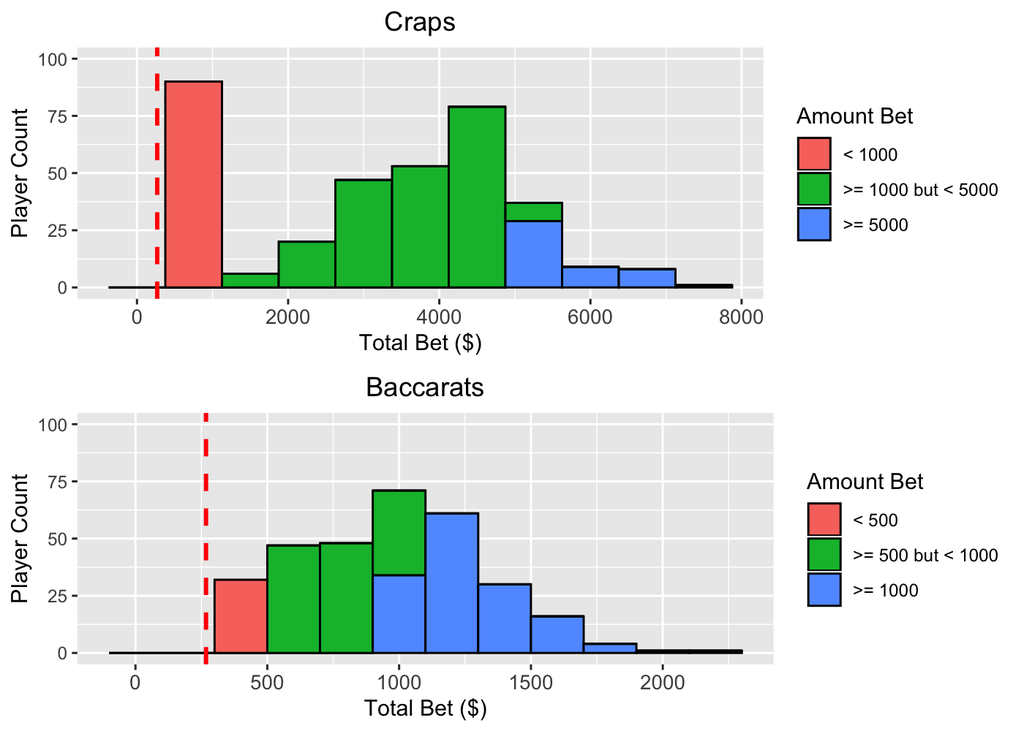

```
##
## $`3`
```

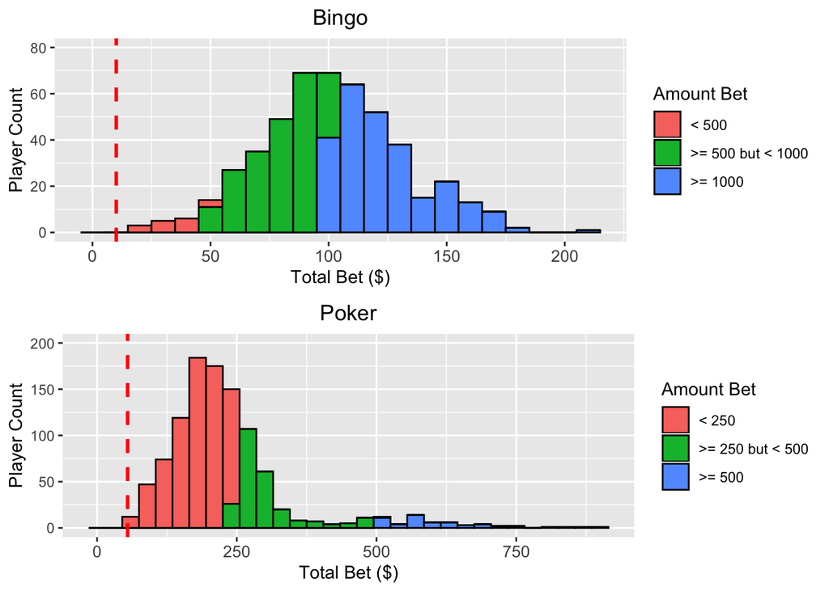

```
##
## $`4`
```

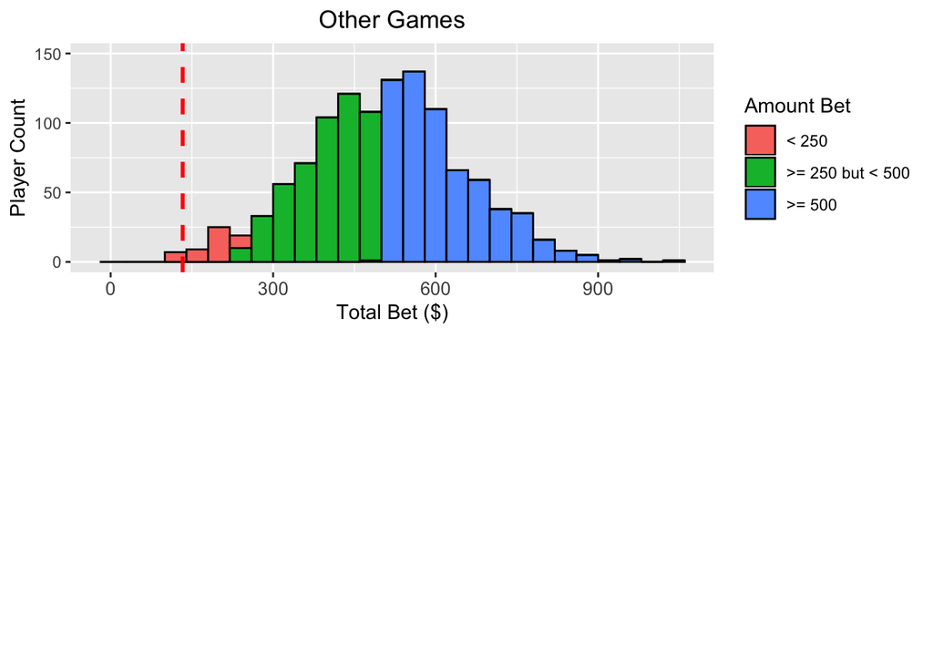

```
##
## attr(,"class")
## [1] "list"      "ggarrange"
```

Use a K-Means Cluster Analysis to create the groupings that will help management to determine what type (and value) of comps should be offered to players in each grouping. Keep the number of groups in the 3-6 range (K=3 to 6). Show the K=6 results as a Scatter plot Matrix showing every combination of two games (i.e. use the pairs function from the cars package)

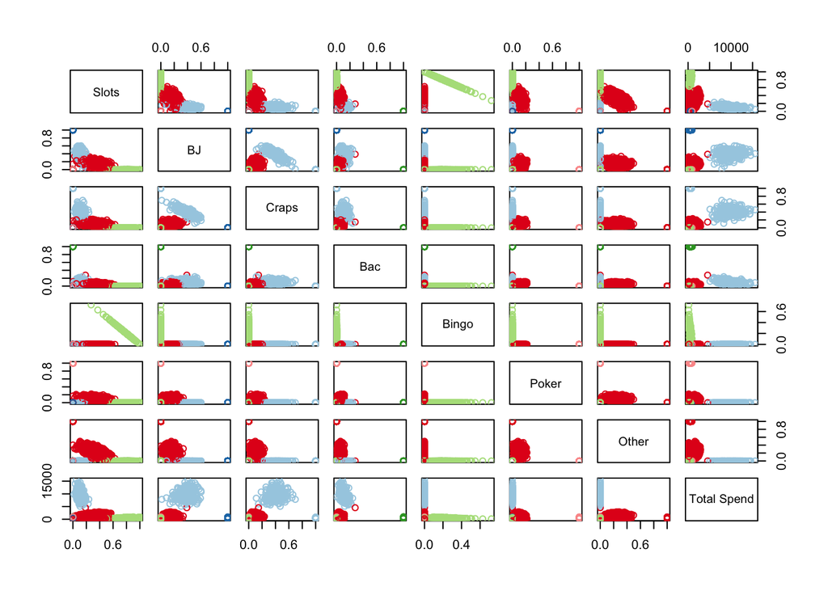

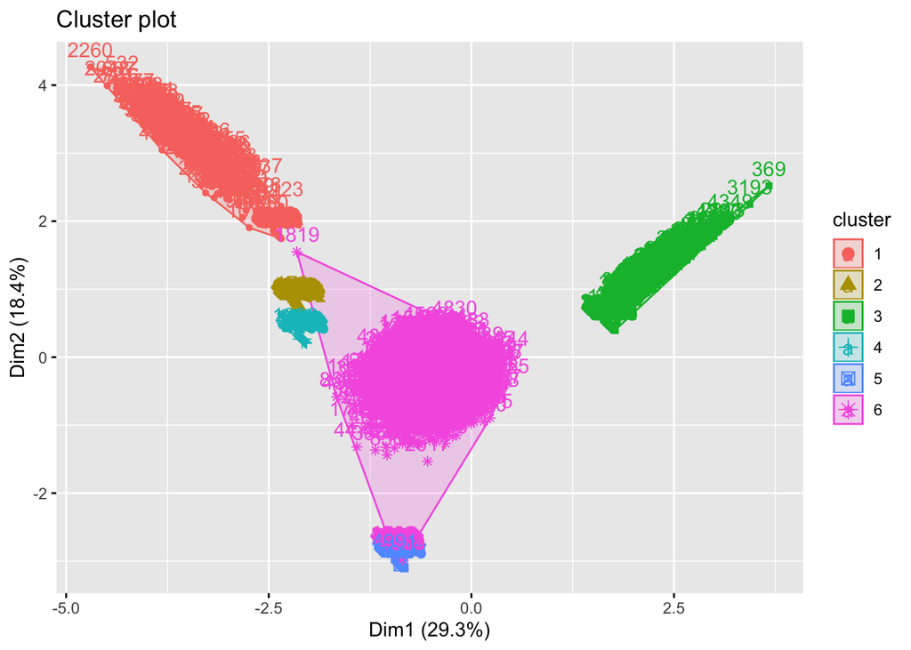